# Risk Theory 2020/21 Assignment 2

Jiyeon Kim (12470236), Younjoo Mo (12475440)

4/20/2021

# Makeham and Gompertz mortality laws

## 1 Reading the data, basic calculations

```r
# Numbers of people that died at ages x = 0,1,2,...,94

d.x <- scan(text="
2618 390 85 41 26 26 30 32 34 33 22 37 28 32 25
20 36 38 29 27 30 38 28 38 52 33 48 49 45 48
51 55 56 55 67 76 82 104 92 114 94 121 139 152 163
205 196 237 275 296 343 382 421 526 582 622 742 878 921 1075
1216 1398 1594 1840 1923 2253 2483 2688 3186 3346 3710 3817 4121 4490 4688
4734 4864 4884 4756 4560 4120 3740 3385 2756 2079 1563 1086 727 455 228
103 42 17 7 1")

sum(d.x)
```

```
## [1] 1e+05
```

#### Question 1(a)

```r
# Reconstructing the sorted sample k(1),k(2),...,k(100000)

k.sorted <- rep((0:94), d.x)

length(k.sorted)
```

```
## [1] 100000
```

```r
sum(k.sorted[1:2618])  ## sum(the 1st 2618 entries)
```

```
## [1] 0
```

```r
sum(k.sorted[2619:(2619+390-1)])  ## sum(the next 390 entries)
```

```
## [1] 390
```

#### Question 1(b)

```r
tail(k.sorted, 10)  ## consistent with the info. in d.x. (d.93 = 7, d.94 = 1)
```

```
##  [1] 92 92 93 93 93 93 93 93 93 94
```

#### Question 2

```r
n.x <- rev(cumsum(rev(d.x)))

length(n.x)
```

```
## [1] 95
```

```r
head(n.x, 3)  ## correct
```

```
## [1] 100000  97382  96992
```

```r
tail(n.x, 3)  ## correct
```

```
## [1] 25  8  1
```

```r
# Pr[ dying at each age x | surviving up to the x-th birthday]

fr <- d.x/n.x
```

## 2 Makeham’s mortality law

```r
# Survival function for the Makeham distribution (a≥0, b≥0, c>1)

sMakeham <- function (x, a, b, c) {
  ifelse(x<0, 1, exp(-a*x-b/log(c)*(c^x-1)))
}
```

#### Question 3(a)

```r
dMakeham <- function (k, a, b, c) {
  ifelse(k>floor(k), 0, (sMakeham(k,a,b,c)-sMakeham(k+1,a,b,c)))
}
```

#### Question 3(b)

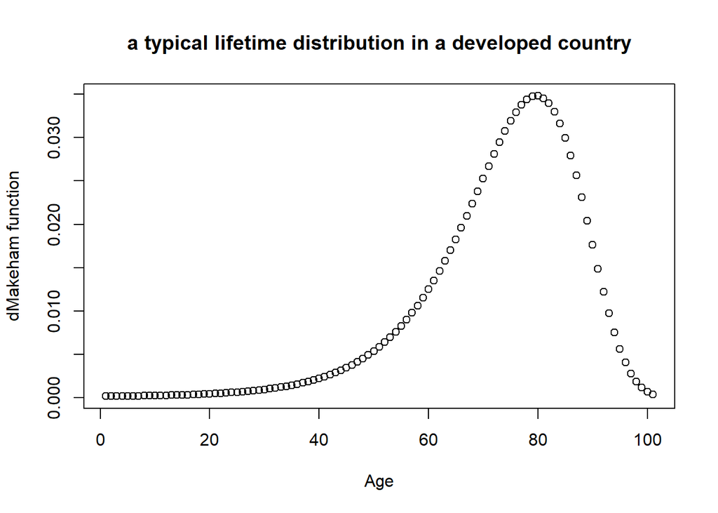

```r
plot(dMakeham(0:100, 1e-4, 5e-5, 1.1),
     xlab="Age", ylab="dMakeham function", main="a typical lifetime distribution in a developed country")
```

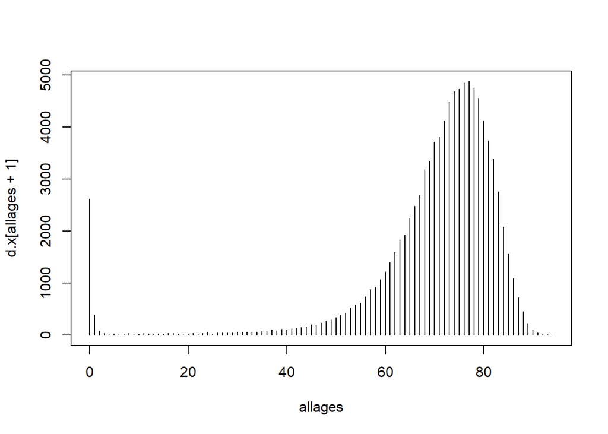

```r
# Graphically illustrating the data

allages <- 0:(length(d.x)-1) ## ages from 0 to 94
plot(allages, d.x[allages+1], type="h")
```

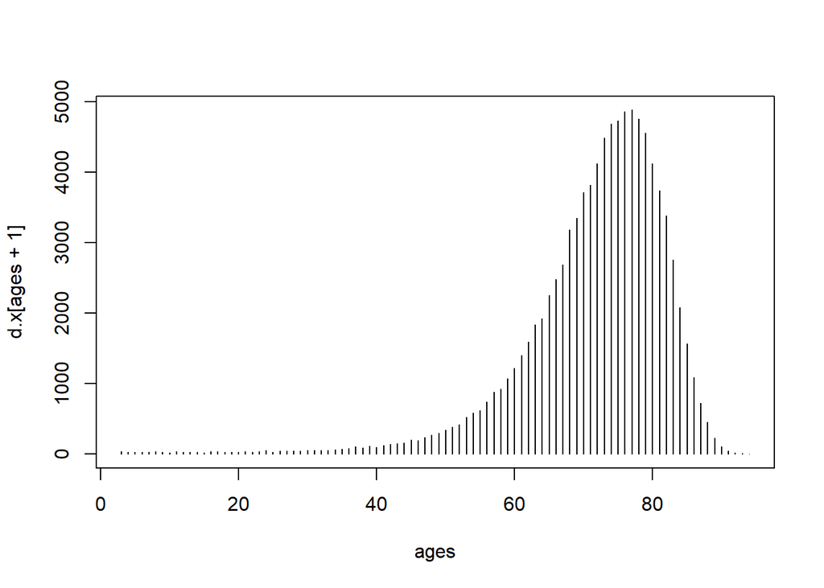

```r
ages <- allages[allages>=3] ## ages from 3 to 94
plot(ages, d.x[ages+1], type="h")
```

## 3 Maximum likelihood estimates of the Makeham parameters

```r
# Negative log-likelihood of Makeham parameters

negloglikMakeham <- function (abc) {
  -sum(d.x[ages+1] * log(dMakeham(ages, abc[1], abc[2], abc[3])))
}
```

#### Question 4

```r
# Minimizing negloglikMakeham

ooMakeham <- optim(c(1e-4, 5e-5, 1.1), negloglikMakeham)
```

[output not shown]

```r
# Maximum likelihood estimates

a.hat <- ooMakeham$par[1]
b.hat <- ooMakeham$par[2]
c.hat <- ooMakeham$par[3]
```

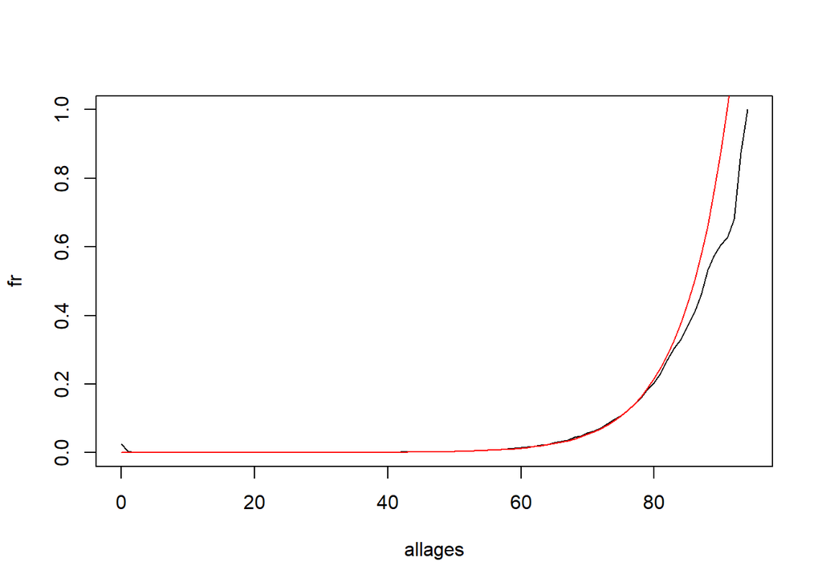

```r
# Plotting estimated mortality

plot(allages, fr, type="l")  ## plot non-parametric mortality estimate
lines(allages, a.hat+b.hat*c.hat^allages, col="red")  ## plot Makeham mortality estimate
```

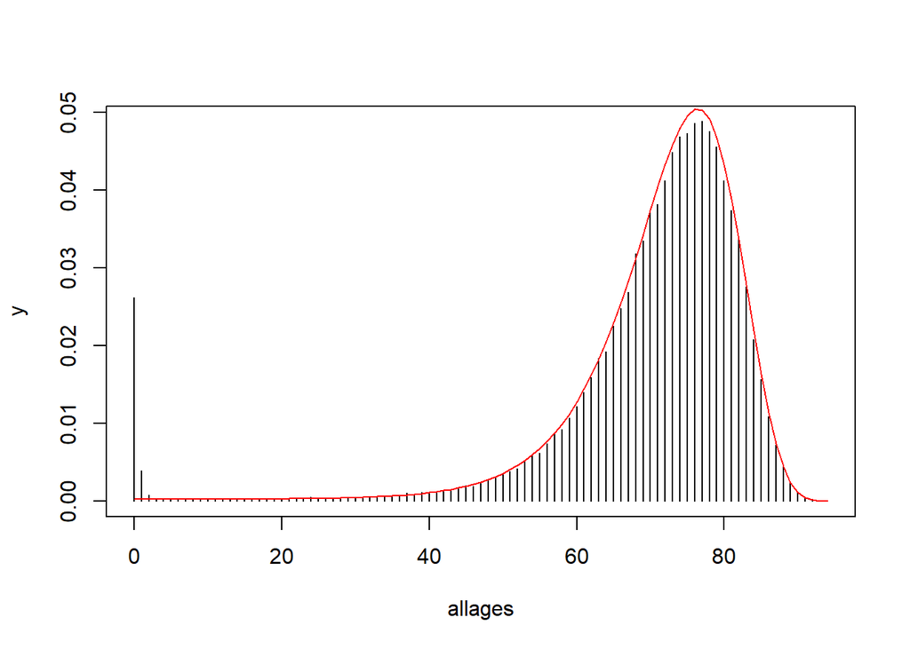

```r
# Plotting density

y <- d.x/sum(d.x) ## observed fractions of deaths at each age
plot(allages, y, type="h")  ## plot observed fractions of deaths at each age
lines(allages, dMakeham(allages, a.hat, b.hat, c.hat), col="red")  ## Makeham density
```

## 4 Expected lifetime, number of retirement years

```r
# Expected age-at-death (estimated via the fitted Makeham distribution)

integrate(sMakeham, 0, Inf, a.hat, b.hat, c.hat)
```

```
## 72.05195 with absolute error < 0.00093
```

```r
# Expected age-at-death (estimated via the sample average)

sum((allages+0.5)*d.x) / sum(d.x)
```

```
## [1] 69.85531
```

#### Question 5(a)

If we use ‘allages’, our computation implies that all people has died on their birthday. This is unrealistic.

We should consider that people could pass away at any moment, and adjust our computation.

One option we can choose is to assume Uniform Distribution of Deaths(UDD) in each year of age. Under UDD, we can say that people who died between the age $x$ and $x+1$ have averagely survived for $x+0.5$ years.

Therefore, using ‘allages+0.5’ is reasonable rather than ‘allages’.

#### Question 5(b)

The difference is caused by high infant mortality.

The sample data $d_x$ shows high infant mortality for $x = 0, 1, 2$. And this feature has been reflected in the expected age-at-death estimated via sample average.

On the other hand, we optimized the Makeham distribution model excluding the data of age 0,1,2. So the expected age-at-death estimated via the fitted Makeham distribution is relatively high.

```r
# Vector counting the number of pension years for each age-at-death

pension.years <- pmax(allages + 0.5 - 65, 0)

# Sample mean of pension years

sum(pension.years*d.x) / sum(d.x)
```

```
## [1] 8.624185
```

#### Question 6(a)

```r
integrate(sMakeham, 65, Inf, a.hat, b.hat, c.hat)
```

```
## 8.898422 with absolute error < 4.8e-05
```

As it is mentioned in Question 5(b), the total sample has much higher infant mortality than the fitted Makeham distribution. This means that the probability of reaching at age 65 is lower when it is computed from the sample data. Thus, the sample mean of pension years is relatively low.

#### Question 6(b)

```r
sum(pension.years*d.x) / n.x[65+1]
```

```
## [1] 10.93205
```

#### Question 6(c)

```r
sMakeham.65 <- sMakeham(65, a.hat, b.hat, c.hat)
sMakeham.65^(-1) * integrate(sMakeham, 65, Inf, a.hat, b.hat, c.hat)$value
```

```
## [1] 10.94129
```

#### Question 6(d)

The sample data and the fitted Makeham distribution fits quite well for age 65+. So if once a person survives until 65-year-old, the expected future lifetime is estimated in a similar value. Therefore, the results from (b) and (c) are close to each other.

## 5 Proportional hazard models

#### Question 7

$$\begin{align}
& S_X(x) = \exp\Bigg(-\int_0^x\mu_X(t)dt\Bigg),\hspace{2ex} (x>0)\\
& \mu_X^{new}(x)=f\cdot\mu_X(x)
\end{align}$$

$$\begin{align}
S_X^{new}(x) & = \exp\Bigg(-\int_0^x\mu_X^{new}(t)dt\Bigg)\\
& = \exp\Bigg(-\int_0^x\ f\cdot\mu_X(t)dt\Bigg)\\
& = \exp\Bigg(-f \cdot \int_0^x\ \mu_X(t)dt\Bigg)\\
& = \Bigg[\exp\Bigg(- \int_0^x\ \mu_X(t)dt\Bigg)\Bigg]^f
\end{align} \\
S_X^{new}(x) = \big[S_X(x)\big]^f, \hspace{2ex} (x > 0) \hspace{7.5ex}$$

#### Question 8(a)

```r
k <- c(-3, -2, -1, 0, 1, 2, 3)
f <- 2^k
exp.lifetimes <- rep(0, 7)

for(i in 1:7){
  a.hat.new <- f * a.hat
  b.hat.new <- f * b.hat
  exp.lifetimes[i] <- integrate(sMakeham, 0, Inf, a.hat.new[i], b.hat.new[i], c.hat)$value
}
exp.lifetimes
```

```
## [1] 87.51230 82.45562 77.32054 72.05195 66.56067 60.70884 54.29973
```

#### Question 8(b)

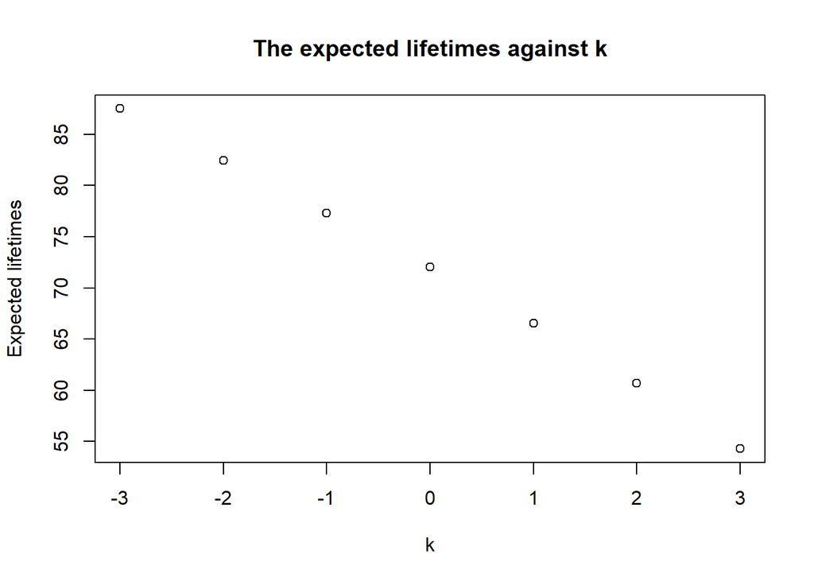

```r
plot(k, exp.lifetimes,
     xlab = "k", ylab = "Expected lifetimes", main = "The expected lifetimes against k")
```

```r
reduction.amount <- exp.lifetimes[1:6] - exp.lifetimes[2:7]
reduction.amount
```

```
## [1] 5.056675 5.135087 5.268587 5.491278 5.851837 6.409102
```

```r
mean(reduction.amount)  ## The expected age-at-death drops averagely by 5.54.
```

```
## [1] 5.535428
```

## 6 Reducing Makeham’s law to Gompertz’

#### Question 9(a)

```r
# Three functions for Gompertz distribution

sGompertz <- function (x, b, c) {
  ifelse(x<0, 1, exp(-b/log(c)*(c^x-1)))
}

dGompertz <- function (k, b, c) {
  ifelse(k>floor(k), 0, (sGompertz(k,b,c)-sGompertz(k+1,b,c)))
}

negloglikGompertz <- function (bc) {
  -sum(d.x[ages+1] * log(dGompertz(ages, bc[1], bc[2])))
}

# Minimizing negloglikGompertz

ooGompertz <- optim(c(b.hat, c.hat), negloglikGompertz)
```

[output not shown]

```r
# Maximum likelihood estimates

b.hat.Gompertz <- ooGompertz$par[1]
c.hat.Gompertz <- ooGompertz$par[2]
```

#### Question 9(b)

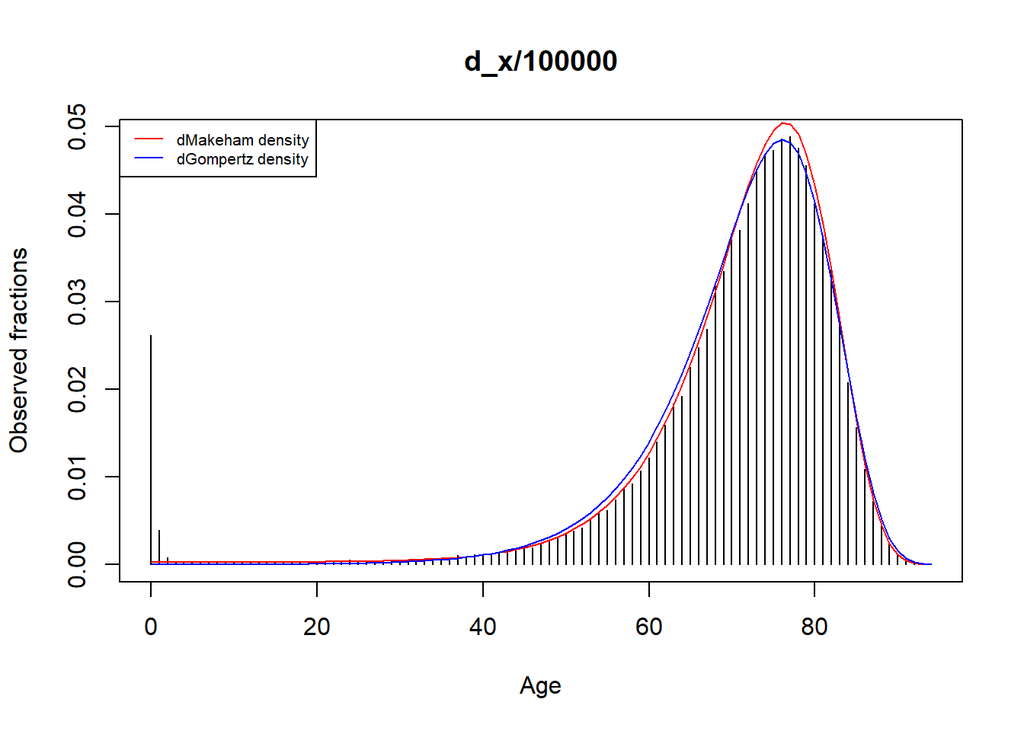

```r
# comparison Gompertz density vs observed fractions
plot(allages, y, type="h", xlab = "Age", ylab = "Observed fractions", main = "d_x/100000")  ## plot observed fractions of deaths at each age
lines(allages, dMakeham(allages,a.hat,b.hat,c.hat), col="red")                ## Makeham density
lines(allages, dGompertz(allages,b.hat.Gompertz,c.hat.Gompertz), col="blue")  ## Gompertz density
legend("topleft", c("dMakeham density","dGompertz density") ,col= c("red","blue"), cex =0.65, lty=1)
```

It seems that the Makeham distribution fits the observed data better. Because Gompertz has too low infant mortality, and it overestimates mortality between age around 45 to 65. Although Makeham overestimates mortality between age around 70 to 80, it might not be a critical problem, considering the relative difference between the Makeham mortality and the observed mortalities. Thus, we assume that Makeham fits better.

#### Question 9(c)

```r
# Making vectors of MLE

Makeham.hats <- c(a.hat, b.hat, c.hat)
Gompertz.hats <- c(b.hat.Gompertz, c.hat.Gompertz)

# AIC for the Makeham model

2*3 + 2*negloglikMakeham( Makeham.hats )
```

```
## [1] 699908.4
```

```r
# AIC for the Gompertz model

2*2 + 2*negloglikGompertz( Gompertz.hats )
```

```
## [1] 702167.6
```

The Makeham model has the lower AIC value than the Gompertz model. In other words, the Makeham model fits better according to the AIC.